# hw_4

Holden Mitchell

9/23/2017

# Homework 4

### Section 1: (6 graphs)

- High-density scatter plots (plus Smooth Scatter)

High Density

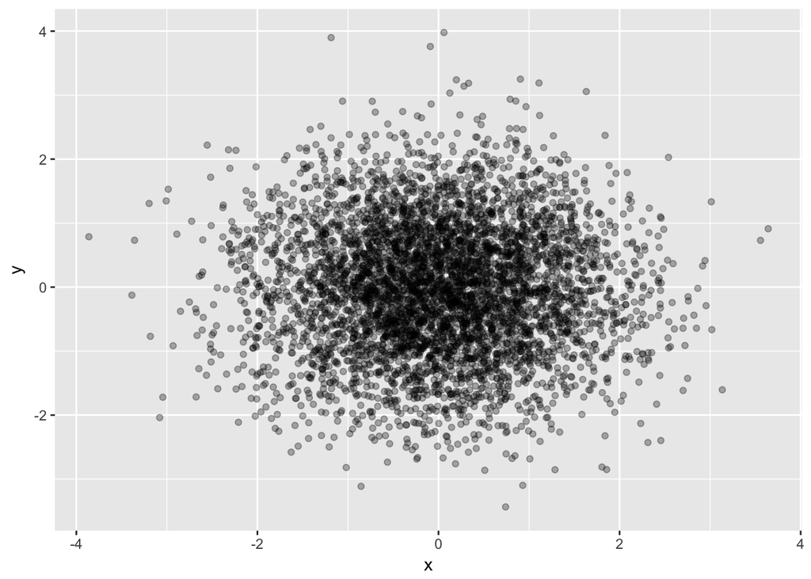

```r
df <- data.frame(x = rnorm(5000),y=rnorm(5000))
ggplot(df,aes(x=x,y=y)) + geom_point(alpha = 0.3)
```

- Smooth Scatter

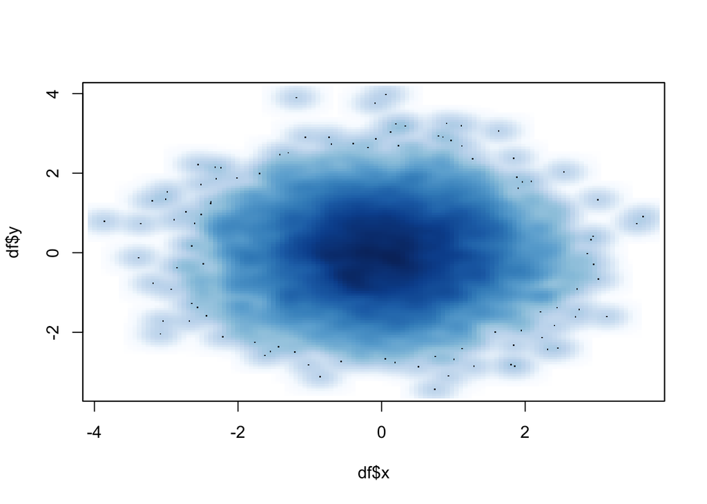

```r
smoothScatter(df$x, df$y)
```

- 3D Scatter Plot (plus interactive)

```r
data(iris)
head(iris)
```

```
##   Sepal.Length Sepal.Width Petal.Length Petal.Width Species
## 1          5.1         3.5          1.4         0.2  setosa
## 2          4.9         3.0          1.4         0.2  setosa
## 3          4.7         3.2          1.3         0.2  setosa
## 4          4.6         3.1          1.5         0.2  setosa
## 5          5.0         3.6          1.4         0.2  setosa
## 6          5.4         3.9          1.7         0.4  setosa
```

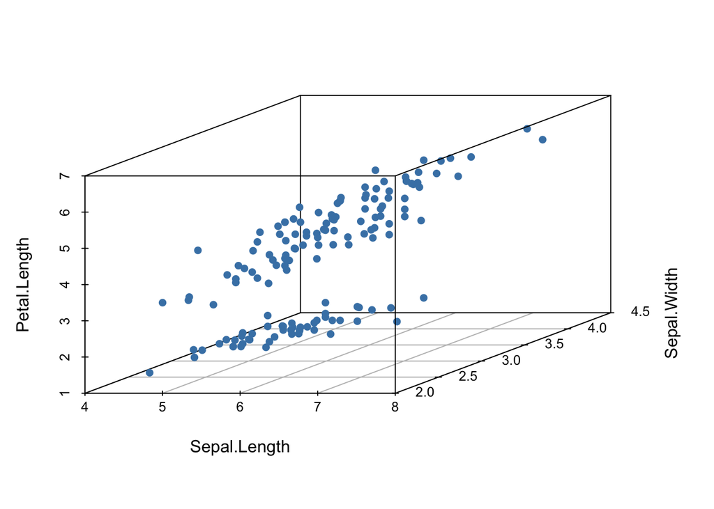

```r
scatterplot3d(iris[,1:3], pch = 16, color="steelblue")
```

* Interactive

Ran into an issue due to X11 not being on my MAC, which is a dependency of the library rgl. I tried to instal X12 to see if that would work but had no luck. I think that the code below should work, but I did not test it since I could not load the rgl library.

```r
# scatter3d(iris[,1:3], pch = 16, color="steelblue")
```

- Bubble Plot

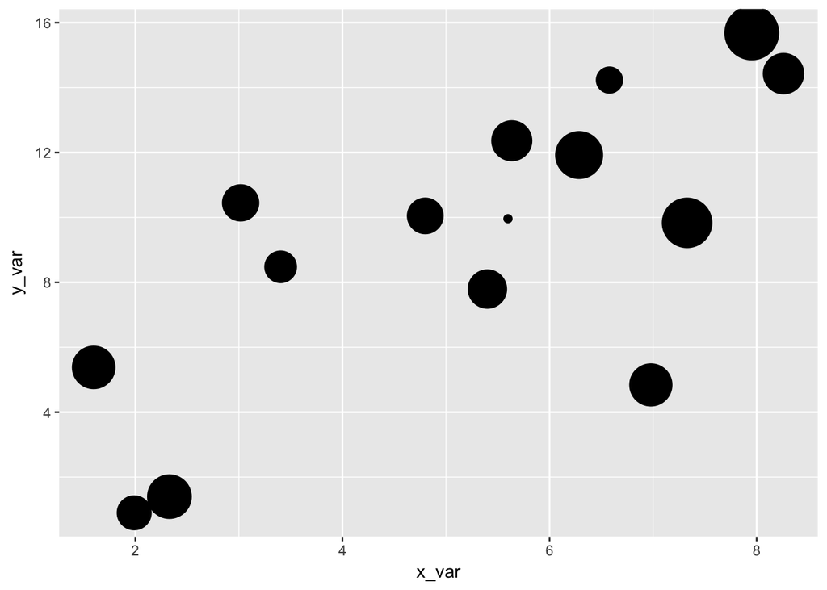

```r
set.seed(53)
x_var <- rnorm( n = 15, mean = 5, sd = 2)
y_var <- x_var + rnorm(n = 15, mean = 5, sd =4)
size_var <- runif(15, 1,10)

df.test_data <- data.frame(x_var, y_var, size_var)

ggplot(data=df.test_data, aes(x=x_var, y=y_var)) +
  geom_point(aes(size=size_var)) +
  scale_size_continuous(range=c(2,15)) +
  theme(legend.position = "none")
```

- Corrgram

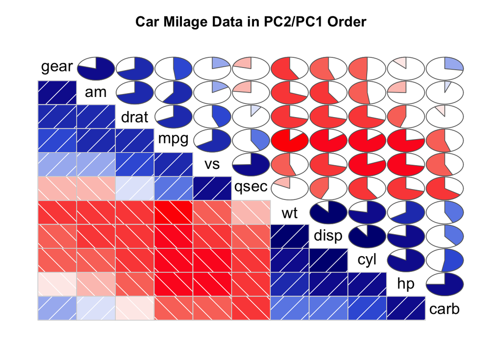

```r
corrgram(mtcars, order=TRUE, lower.panel=panel.shade,
  upper.panel=panel.pie, text.panel=panel.txt,
  main="Car Milage Data in PC2/PC1 Order")
```

### Section 2:

- 4-3, 4-6, 4-31, 4-65

##### 4-3

##### Find the following probabilities:

- P(-1 < Z < 1) = 0.6826

```r
pnorm(1) - pnorm(-1)
```

```
## [1] 0.6826895
```

- P(-1.96 < Z < 1.96) = 0.95

```r
pnorm(1.96) - pnorm(-1.96)
```

```
## [1] 0.9500042
```

- P(-2.33 < Z < 2.33) = 0.9802

```r
pnorm(2.33) - pnorm(-2.33)
```

```
## [1] 0.9801938
```

##### 4-6

Find two values, equidistant from 0 on either side, such that the probability that a standard normal random variable will be between them is 0.4

```r
pnorm(.5244) - pnorm(-0.5244)
```

```
## [1] 0.3999996
```

Answer: -.5244, .5244

##### 4-31

Let X be a normally distributed random variable with mean 410 and standard deviation 2. Find the probability that X will be between 407 and 415

```r
pnorm(415, mean=410, sd=2) - pnorm(407, mean=410, sd=2)
```

```
## [1] 0.9269831
```

- 0.927

##### 4-65

Normally distributed.

```r
means = c(5780, 641, 712)
standard_deviations = c(142,78,72)
rest_data = data.frame(names = c("Eat In", "Takeout", "Bar"), mean=means, standard_deviation=standard_deviations, variance=standard_deviations^2)
```

- 1. Will the total revenue on a day be normally distributed?

Answer: Yes

- 2. What are the mean and standard deviation of the total revenue on a particular day?

```r
sum(rest_data$mean)
```

```
## [1] 7133
```

```r
sqrt(sum(rest_data$variance))
```

```
## [1] 177.2907
```

Mean = 7133 sd = 177.29

- 3. What is the probability that the revenue will exceed $7,000 on a particular day?

```r
pnorm(7000, mean=7133, sd=177.29, lower.tail = FALSE)
```

```
## [1] 0.7734278
```

0.7734

### Section 3:

- 5-8, 5-13, 5-26, 5-39, 5-65

##### 5-8

Compute an estimate of the mean amount of all accounts receivable. Give an estimate of the variance of all the amounts.

```r
accounts = c(87.5, 123.1, 45.3, 52.22, 213, 155, 39, 76.05, 49.8, 99.99, 132, 102.11)

mean(accounts)
```

```
## [1] 97.9225
```

```r
var(accounts)
```

```
## [1] 2686.38
```

- Mean = 97.923
- Variance = 2686.38

##### 5-13

mean = 3.9% sd = 1.2% sample = 36

If a random sample of 36 companies in the S&P 500 is selected, what is the probability that their average return for this period will be between 7% and 4%?

```r
mean = 3.9
sd = 1.2
upper = 7
lower = 4

num = (4 - 3.9) / (1.2 / sqrt(36))
z1 = pnorm(num, lower.tail = FALSE)
num = (7 - 3.9) / (1.2 / sqrt(36))
z2 = pnorm(num, lower.tail = FALSE)
z1 - z2
```

```
## [1] 0.3085375
```

Answer: 0.3085

##### 5-26

```r
mean = 3.4
sd = 1.5
sample = 100
```

What is the probability >= 3.6?

```r
num = (3.6 - mean) / (sd / sqrt(100))
pnorm(num, lower.tail = FALSE)
```

```
## [1] 0.09121122
```

Answer: 0.0912

##### 5-39

```r
data_points = c(34,51,40,38,47,50,52,44,37)
```

- 1. What number?
- What is the minimized?
- How many degrees of freedom?
- Calculate the mean squared deviation:

```r
mean(data_points)
```

```
## [1] 43.66667
```

```r
var(data_points)*(9-1)
```

```
## [1] 358
```

```r
sd(data_points)^2
```

```
## [1] 44.75
```

- 2. What three number?
- Minimized SSD?
- Degrees of freedom?
- MSD?

```r
data_a<-c(34,51,40,38)
data_b<-c(47,50,52)
data_c<-c(44,37)

data_points = c(mean(data_a), mean(data_b), mean(data_c))
data_points
```

```
## [1] 40.75000 49.66667 40.50000
```

```r
ssd = sum(var(data_a)*(4-1),
var(data_b)*(3-1),
var(data_c)*(2-1))
ssd
```

```
## [1] 195.9167
```

```r
ssd / (9-3)
```

```
## [1] 32.65278
```

- 3. What 9 numbers?
- Minimized SSD?
- Degrees of freedom?
- MSD?

Use each number SSD = 0 df = 0 MSD = 0

- 4. With respect to 50

```r
data_points = c(34,51,40,38,47,50,52,44,37)
data_new = (50 - data_points)
ssd = sum(data_new^2)
ssd
```

```
## [1] 719
```

```r
ssd/9
```

```
## [1] 79.88889
```

SSD = 719 df = 9 MSD = 79.89

##### 5-65

```r
values = c(10.10, 6.94, 13.55, 13.58, 21.42)
```

- 1. Compute the mean and standard deviation of the prices quoted above.

```r
mean(values)
```

```
## [1] 13.118
```

```r
sd(values)
```

```
## [1] 5.399057
```

Mean = 13.118 sd = 5.3991

- 2. 36 banks. average > $1.00 or average < $1.00

```r
m = mean(values)
s = sd(values)

num = (m+1 - m) / (s / sqrt(36))
top = pnorm(num, lower.tail = FALSE)

num = (m-1 - m) / (s / sqrt(36))
bottom = pnorm(num)

top + bottom
```

```
## [1] 0.266437
```

Answer: 0.2664

- 3. 50 bank corporations. Probability average is above $12?

```r
num = (12 - m) / (s / sqrt(50))
pnorm(num, lower.tail = FALSE)
```

```
## [1] 0.9284342
```

Answer: 0.9284

- 4. Criticize all the assumptions you have had to make in solving the previous parts of this problem. Explain your contentions.

It is foolish to assume that 36 much less 50 bank corporations could rely on the mean and standard deviation of a random sample of 5.